# Terrigenous nutrient pulses facilitate shifts in reef fish community structure and feeding through trophic plasticity

Maya Zeff

2025-11-13

# Load packages

```r
# ensure pacman is installed
if (!require("pacman")) install.packages("pacman")

# Data manipulation
pacman::p_load(
  dplyr, tidyr, tibble, stringr,
  # Visualization
  ggplot2,
  ggtext,
  cowplot, ggpubr, gridExtra,
  grid,
  statmod,
  # Statistics
  MASS, lme4,
  rstatix,
  emmeans,
  nlme,
  glmmTMB,
  # Interactive viz
  # Project management
  here, report
)

# create an 'Outputs' directory if one does not exist to save images
if (!dir.exists(here("Outputs"))) {
  dir.create(here("Outputs"))
}
```

# Read in data

```r
# Set seed for reproducibility
set.seed(123)

# Function to construct file path for data loading
read_data <- function(file_name) {
  read.csv(here("Data", file_name))
}

# Load functional groupings data
functional_group <- read_data("species_functional.csv")

# Load camera survey data and preprocess
all_cam <- read_data("video_surveys.csv") %>%
  mutate(
    # Standardize tide levels
    Tide = as.factor(case_when(
      Tide == "High" ~ "High Tide",
      Tide == "Low" ~ "Low Tide"
    )),
    # Group substrates into broader categories
    substrate = as.factor(case_when(
      Substrate %in% c("turbinaria", "coral", "turf", "sand", "macroalgae") ~ "Benthos",
      Substrate == "plankton" ~ "Water Column"
    )),
  ) %>%
  # Merge with functional group data based on species codes
  mutate(code = Code) %>%
  left_join(functional_group, by = 'code') %>%
  # remove highly mobile species
  filter(!family %in% c("Carangidae", "Carcharhinidae", "Beloniformes")) %>%
  # Remove piscivores due to insufficient observations (n < 3 individuals total)
  filter(functional != "Piscivore")


# Load herbivory assay data and preprocess
assay <- read_data("herbivory_assay.csv") %>%
  # calculate amount consumed
  mutate(diff = Pre_algae_g-Post_algae_g ) %>%
  # split Group column
  separate(col = Group, into = c("habitat", "environment"), sep = "(?<=Reef|Sand)") %>%
  # rename columns
  mutate(source = as.factor(Source),
         cage = as.factor(Place),
         date = factor(Date,
                       levels = c("19/7/2022", "29/6/2022"),
                       labels = c("Day1", "Day2")),
         replicate = as.factor(Replicate)) %>%
  # select desired
  dplyr::select(date, habitat, environment, replicate, source, cage, diff)


# Load site selection salinity & pH data
carb_chem <- read_data("water_chemistry.csv") %>%
  as_tibble() %>%
  # rename sampling times to day/night and high tide/low tide
  mutate(
    Environment = str_replace(Environment, "SGD", "SGD Environment"),
    Environment = str_replace(Environment ,"Ambient","Ambient Environment"),
    SamplingTime = str_replace(SamplingTime, "08:00", "Day Low Tide"),
    SamplingTime = str_replace(SamplingTime, "14:00", "Day High Tide"),
    SamplingTime = str_replace(SamplingTime, "20:00", "Night Low Tide"),
    SamplingTime = str_replace(SamplingTime, "02:00", "Night High Tide")
  ) %>%
  dplyr::select(Replicate, Habitat, Environment, Tide, SamplingTime, TA, Salinity, pH) %>%
  mutate(
    # rename tidal states
    Tide = case_when(
      Tide == "Low" ~ "Low Tide",
      Tide == "High" ~ "High Tide"
    ),
    # rename habitats
    Habitat = case_when(
      Habitat == "Reef" ~ "Reef Habitat",
      Habitat == "Sand" ~ "Sand Habitat"
    ),
    # turn columns into factors and relevel if necessary for plotting
    Environment = factor(Environment, levels = c("SGD Environment", "Ambient Environment")),

    # create facet group of habitat & SGD environment
    Facet_Group = paste(Habitat, Environment, sep = " "),
    # set order for group levels
    Facet_Group = factor(
      Facet_Group,
      levels = c(
        "Reef Habitat SGD Environment",
        "Sand Habitat SGD Environment",
        "Sand Habitat Ambient Environment",
        "Reef Habitat Ambient Environment"
      )
    )
  )

# Load Turbinaria ornata nutrient data
turbinaria <- read_data("turbinaria_nutrients.csv") %>%
  # Convert nitrogen measurements to percent content
  mutate(percent_N = (ug_N / weight_mg) * 0.1,
         # Standardize SGD treatment labels
         Environment = str_replace(Environment, "SGD", "SGD Environment"),
         Environment = str_replace(Environment ,"Ambient","Ambient Environment"))

# Load Padina boryana nutrient data
padina <- read_data("padina_nutrients.csv") %>%
  # Convert nitrogen measurements to percent content
  mutate(percent_N = (ug_N / weight_mg) * 0.1,
         # Standardize SGD treatment labels
         Environment = str_replace(Environment, "SGD", "SGD Environment"),
         Environment = str_replace(Environment ,"Ambient","Ambient Environment"))
```

# Figure styling

```r
# Set colors
ambient_color <- "steelblue"
sgd_color <- "darkolivegreen"

# Define consistent table theme
table_theme <- ttheme_default(
  core = list(
    # Body text size
    fg_params = list(fontsize = 10),
    # Alternating row colors for readability
    bg_params = list(fill = c("white", "grey95"))
  ),
  colhead = list(
    # Header text: larger and bold
    fg_params = list(fontsize = 11, fontface = "bold"),
    # Header background: darker grey
    bg_params = list(fill = "grey85")
  )
)
```

# Figure 1.

1. Map of Mo’orea showing study location and (B) experimental site configuration with SGD-influenced sites positioned down-current of the groundwater seep (black circle) and ambient sites up-current. (C) Underwater camera deployment for fish community surveys and (D) herbivory assay setup showing paired Padina boryana specimens in mesh enclosures. (E-F) Mean salinity (± SE) across tidal cycles in SGD and ambient environments. Letters indicate significant differences between tides within each environment (Gamma GLMM, p < 0.05). (G) Mean percent nitrogen content (± SE) of Turbinaria ornata specimens collected from ambient and SGD environments, with letters indicating significant differences between environments (Gamma GLM, p < 0.001). Together, these data highlight the tidally-driven influx of nutrient-rich freshwater at our SGD sites.

## Plotting

Sub-plots A and B were made in ArcGIS and compiled with photographs (C,D) and the following plots (E, F) using Canva.

### Fig. 1, Subplots E & F

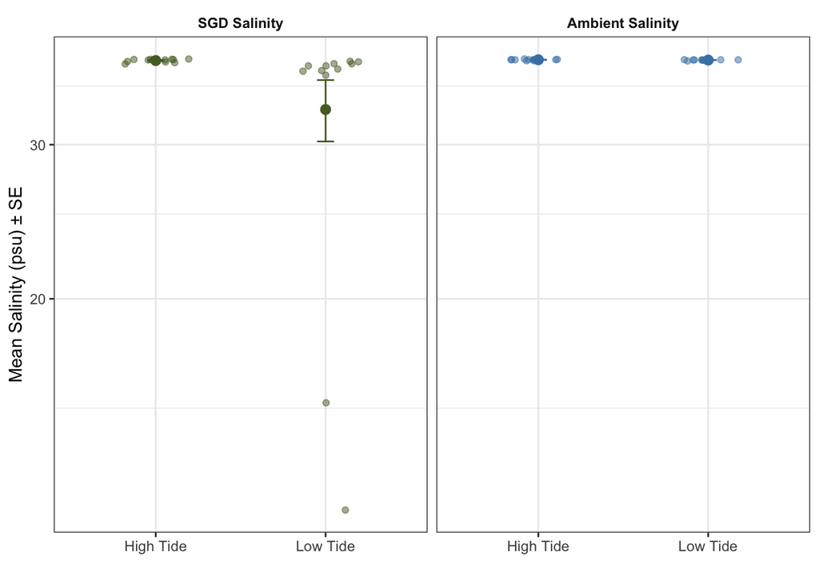

```r
# Calculate summary statistics for plot layers
salinity_summary <- carb_chem %>%
  group_by(Environment, Tide) %>%
  summarize(
    mean_salinity = mean(Salinity, na.rm = TRUE),
    se_salinity = sd(Salinity, na.rm = TRUE) / sqrt(n()),
    .groups = "drop"
  )

# Generate main figure
Fig1EF <- carb_chem %>%
  ggplot() +

  # Display individual observations with horizontal jitter to reduce overplotting
  geom_jitter(
    aes(x = Tide, y = Salinity, color = Environment),
    width = 0.2,      # Jitter width for x-axis separation
    alpha = 0.5       # Transparency to show overlapping points
  ) +

  # Overlay group means as solid points
  geom_point(
    data = salinity_summary,
    aes(x = Tide, y = mean_salinity, color = Environment),
    size = 2.5        # Larger size to distinguish from raw data
  ) +

  # Add standard error bars around means
  geom_errorbar(
    data = salinity_summary,
    aes(x = Tide,
        ymin = mean_salinity - se_salinity,
        ymax = mean_salinity + se_salinity,
        color = Environment),
    width = 0.1       # Horizontal cap width
  ) +

  # Apply project color scheme
  scale_color_manual(
    values = c(
      "SGD Environment" = sgd_color,
      "Ambient Environment" = ambient_color
    )
  ) +

  # Log-transform y-axis to better display the large salinity reduction in SGD at low tide
  coord_trans(y = "log") +

  # Create side-by-side panels for direct comparison
  facet_wrap(
    ~Environment,
    nrow = 1,
    labeller = labeller(
      Environment = c(
        "SGD Environment" = "SGD Salinity",
        "Ambient Environment" = "Ambient Salinity"
      )
    )
  ) +

  # Format axes and labels
  labs(
    x = "",
    y = "Mean Salinity (psu) ± SE"
  ) +

  # Apply theme
  theme_bw() +
  theme(
    legend.position = "none",          # Remove redundant legend
    strip.background = element_rect(   # Clean panel headers
      fill = "white",
      color = NA
    ),
    strip.text = element_text(         # Emphasize panel labels
      face = "bold"
    ),
    axis.text.x = element_text(        # Enhance readability
      size = 9
    )
  )

Fig1EF
```

```r
# Export figure
ggsave(
  filename = here("Outputs", "Fig1EF.png"),
  plot = Fig1EF,
  width = 4,
  height = 2.5,
  dpi = 500
)
```

### Fig. 1, Subplot G

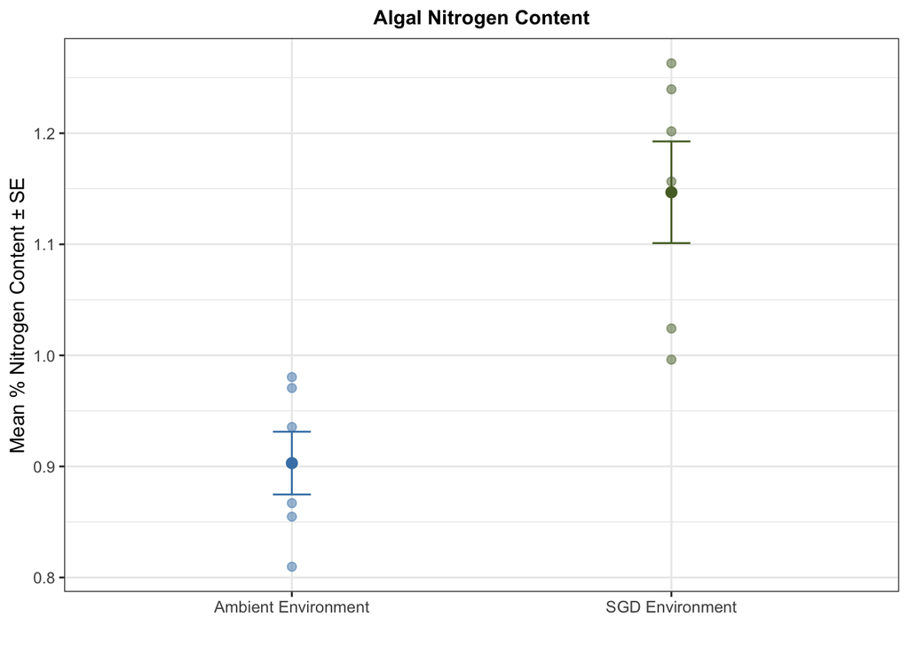

```r
# Calculate summary statistics for nitrogen content by environment
turbinaria_summary <- turbinaria %>%
  group_by(Environment) %>%
  summarize(
    mean_percentN = mean(percent_N),
    se_percentN = sd(percent_N) / sqrt(n()),
    .groups = "drop"
  )

# Generate nitrogen content comparison figure
Fig1G <- ggplot(
  data = turbinaria,
  aes(x = Environment, y = percent_N, color = Environment)
) +

  # Display individual macroalgal samples with horizontal jitter
  geom_jitter(
    alpha = 0.5,
    position = position_dodge(width = 0.3), # Prevent overplotting
    size = 2
  ) +

  # Overlay environment means as larger points
  geom_point(
    data = turbinaria_summary,
    aes(x = Environment, y = mean_percentN),
    size = 2.5    # Distinguish means from raw data
  ) +

  # Add standard error bars to show uncertainty
  geom_errorbar(
    data = turbinaria_summary,
    aes(x = Environment,
        y = mean_percentN,
        ymin = mean_percentN - se_percentN,
        ymax = mean_percentN + se_percentN),
    width = 0.1  # Error bar cap width
  ) +

  # Apply project color scheme
  scale_color_manual(
    values = c(
      "SGD Environment" = sgd_color,
      "Ambient Environment" = ambient_color
    )
  ) +

  # Format axes with appropriate expansion for visual clarity
  scale_y_continuous(
    expand = expansion(mult = c(0.05, 0.05))       # 5% padding on both ends
  ) +

  # Label axes and add descriptive title
  labs(
    x = "",                                        # Remove x-axis label
    y = "Mean % Nitrogen Content ± SE",
    title = "Algal Nitrogen Content"               # Centered title acts as panel label
  ) +

  # Apply publication-ready theme
  theme_bw() +
  theme(
    legend.position = "none",                      # Remove redundant legend
    axis.text.x = element_text(size = 9),          # Readable axis labels
    plot.title = element_text(
      face = "bold",                               # Emphasize title
      hjust = 0.5,                                 # Center alignment
      size = rel(1)                                # Relative size scaling
    )
  )

Fig1G
```

```r
# Export figure
ggsave(
  filename = here("Outputs", "Fig1G.png"),
  plot = Fig1G,
  width = 3.5,
  height = 2.5,
  dpi = 500
)
```

## Statistical Analyses

```r
# ------------------------------------
# SALINITY ANALYSIS
# Test a priori hypothesis: SGD reduces salinity during low tide due to freshwater influx
# ------------------------------------


# Fit Gamma GLMM to account for heterogeneous variance across treatments
# Random effects structure accounts for spatial (Habitat) and temporal (SamplingTime) non-independence
salinity_model <- glmmTMB(
  Salinity ~ Environment * Tide + (1|Habitat/SamplingTime),
  data = carb_chem,
  family = Gamma(link = "log")
)

# Test directional hypothesis: High tide > Low tide salinity
salinity_contrasts <- emmeans(salinity_model, ~ Tide | Environment) %>%
  pairs(adjust = "Tukey", side = ">")

# ------------------------------------
# ALGAL NITROGEN CONTENT ANALYSIS
# Test a priori hypothesis: SGD-exposed macroalgae have elevated nitrogen content due to groundwater nutrient enrichment
# ------------------------------------

# Initial model with habitat random effect
turbinaria_mixed <- glmer(
  percent_N ~ Environment + (1|Habitat),
  data = turbinaria,
  family = Gamma(link = "log")
)

# Random effect variance = 0,simplify to fixed effects model
turbinaria_model <- glm(
  percent_N ~ Environment,
  data = turbinaria,
  family = Gamma(link = "log")
)

# Test directional hypothesis: SGD > Ambient nitrogen content
nitrogen_contrast <- emmeans(turbinaria_model, ~ Environment) %>%
  pairs(side = "<")  # No adjustment needed for single comparison
```

## Supplemental Materials

### Table S1.

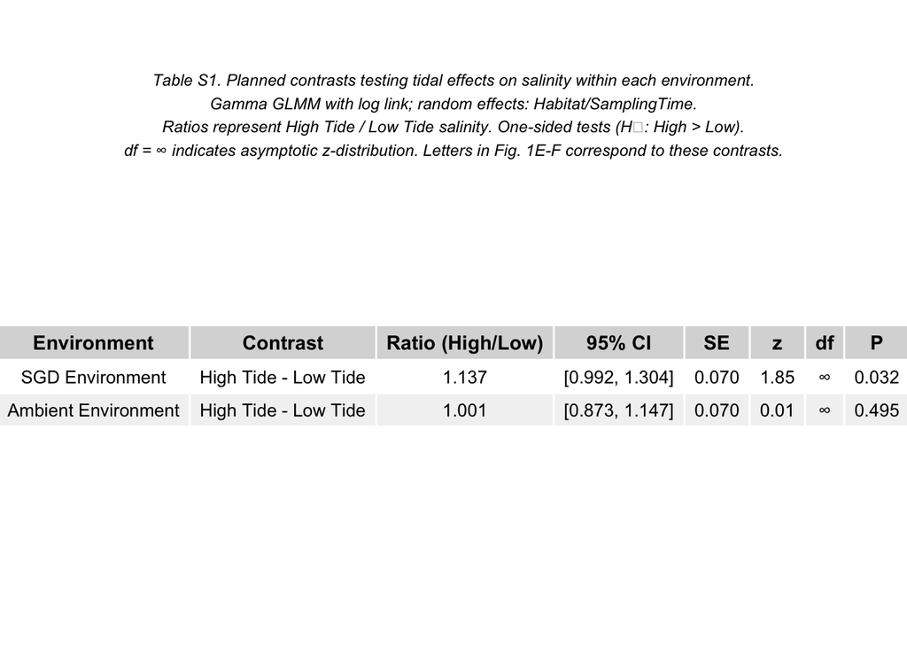

```r
# Get CIs
salinity_contrasts_twosided <- emmeans(salinity_model, ~ Tide | Environment) %>%
  pairs(adjust = "tukey") %>%
  summary(infer = TRUE)

# Get p-values
salinity_contrasts_onesided <- emmeans(salinity_model, ~ Tide | Environment) %>%
  pairs(adjust = "tukey", side = ">") %>%
  summary()

# Combine CIs and p values
salinity_contrasts_df <- as.data.frame(salinity_contrasts_twosided) %>%
  mutate(p.value = as.data.frame(salinity_contrasts_onesided)$p.value)

# For GLMMs with glmmTMB, z-ratios have asymptotic df (effectively infinite)

table_S1 <- salinity_contrasts_df %>%
  mutate(
    # Back-transform to ratio scale
    ratio = exp(estimate),
    ratio_lower = exp(asymp.LCL),
    ratio_upper = exp(asymp.UCL),
    # Format columns
    ratio_formatted = sprintf("%.3f", ratio),
    CI_formatted = sprintf("[%.3f, %.3f]", ratio_lower, ratio_upper),
    SE_formatted = sprintf("%.3f", SE),
    z_formatted = sprintf("%.2f", z.ratio),
    df_note = "∞",  # Asymptotic
    p_formatted = case_when(
      p.value < 0.001 ~ "< 0.001",
      TRUE ~ sprintf("%.3f", p.value)
    )
  ) %>%
  select(Environment, contrast, ratio_formatted, CI_formatted, SE_formatted,
         z_formatted, df_note, p_formatted) %>%
  rename(
    "Environment" = Environment,
    "Contrast" = contrast,
    "Ratio (High/Low)" = ratio_formatted,
    "95% CI" = CI_formatted,
    "SE" = SE_formatted,
    "z" = z_formatted,
    "df" = df_note,
    "P" = p_formatted
  )

caption_S1 <- paste0(

"Table S1. Planned contrasts testing tidal effects on salinity within each environment.\n",
"Gamma GLMM with log link; random effects: Habitat/SamplingTime.\n",
"Ratios represent High Tide / Low Tide salinity. One-sided tests (H₁: High > Low).\n",
"df = ∞ indicates asymptotic z-distribution. Letters in Fig. 1E-F correspond to these contrasts."
)

# Create and save table
table_S1_grob <- tableGrob(table_S1, theme = table_theme, rows = NULL)
title_S1 <- textGrob(caption_S1, x = 0.5, vjust = 0, y = -0.5,
                     gp = gpar(fontsize = 9, fontface = "italic"))
final_S1 <- arrangeGrob(title_S1, table_S1_grob,
                        heights = unit.c(unit(4, "lines"), unit(1, "null")))

png(here("Outputs", "TableS1_updated.png"), width = 10, height = 4, units = "in", res = 300)
grid.draw(final_S1)
dev.off()

# Display inline
grid.draw(final_S1)
```

### Table S2.

[figure not shown]

```r
# Get CIs
nitrogen_contrast_twosided <- emmeans(turbinaria_model, ~ Environment) %>%
  pairs() %>%
  summary(infer = TRUE)

# Get p values
nitrogen_contrast_onesided <- emmeans(turbinaria_model, ~ Environment) %>%
  pairs(side = "<") %>%
  summary()

# Combine CIs and p values
nitrogen_df <- as.data.frame(nitrogen_contrast_twosided) %>%
  mutate(p.value = as.data.frame(nitrogen_contrast_onesided)$p.value)

# For GLM, we get t-ratios with residual df
# Extract residual df from model
resid_df <- df.residual(turbinaria_model)


table_S2 <- nitrogen_df %>%
  mutate(
    ratio = exp(estimate),
    ratio_lower = exp(lower.CL),
    ratio_upper = exp(upper.CL),
    # Percent difference for effect size interpretation
    percent_diff = sprintf("%.1f%%", (1/ratio - 1) * 100),
    ratio_formatted = sprintf("%.3f", ratio),
    CI_formatted = sprintf("[%.3f, %.3f]", ratio_lower, ratio_upper),
    SE_formatted = sprintf("%.3f", SE),
    t_formatted = sprintf("%.2f", t.ratio),
    df_value = resid_df,
    p_formatted = case_when(
      p.value < 0.001 ~ "< 0.001",
      TRUE ~ sprintf("%.3f", p.value)
    )
  ) %>%
  select(contrast, ratio_formatted, CI_formatted, percent_diff, SE_formatted,
         t_formatted, df_value, p_formatted) %>%
  rename(
    "Contrast" = contrast,
    "Ratio (Amb/SGD)" = ratio_formatted,
    "95% CI" = CI_formatted,
    "SGD Increase" = percent_diff,
    "SE" = SE_formatted,
    "t" = t_formatted,
    "df" = df_value,
    "P" = p_formatted
  )

caption_S2 <- paste0(
"Table S2. Planned contrast testing SGD effects on Turbinaria ornata nitrogen content.\n",
"Gamma GLM with log link. Ratio < 1 indicates SGD > Ambient.\n",
"One-sided test (H₁: SGD > Ambient). Letters in Fig. 1G correspond to this contrast."
)

table_S2_grob <- tableGrob(table_S2, theme = table_theme, rows = NULL)
title_S2 <- textGrob(caption_S2, x = 0.5, vjust = 0, y = -0.5,
                     gp = gpar(fontsize = 9, fontface = "italic"))
final_S2 <- arrangeGrob(title_S2, table_S2_grob,
                        heights = unit.c(unit(3, "lines"), unit(1, "null")))

png(here("Outputs", "TableS2_updated.png"), width = 11, height = 3, units = "in", res = 300)
grid.draw(final_S2)
dev.off()

grid.draw(final_S2)
```